# Problem Set 3. Due Thurs March 2 5pm

Eric Prince

Feb 23, 2017

# Submission

1. Fork this repository to your own account
2. Make changes to the `README.Rmd` file (including the author field above).
3. Knit the file to HTML format and add it to your git repository (`git add`)
4. Submit a pull request with your Rmd and knitted HTML files.

# Overview

You will examine a [time-course of mRNA expression](http://www.ncbi.nlm.nih.gov/pubmed/23175786) of barley powdery mildew fungus in immunocompromised plants (*Arabidopsis*). The fungus Blumeria graminis f. sp. hordei (called *Bgh* from now on)

Counts were generated using the [`maSigPro` software](http://bioinformatics.oxfordjournals.org/content/30/18/2598.full) and deposited in [NCBI GEO](http://www.ncbi.nlm.nih.gov/geo/query/acc.cgi?acc=GSE43163).

Some important identifiers for the data set:

| Name | Description |
| --- | --- |
| `A6` | *Bgh* isolate expressing other AVRA effectors |
| `K1` | *Bgh* isolate expressing the cognate AVRA1 effector for MLA1 |
| `pps` | *Arabidopsis* plants |
| `B12` | *Arabidopsis* plants expressing MLA1-HA |

We will download tables from GEO containing counts of mRNA abundance from both the fungal samples.

# Raw data

First we need load the data.

```r
# Load necessary packages
    pkgs <- c("tidyverse",
              "magrittr",
              "stringr",
              "reshape2",
              "cowplot")
    pacman::p_load(pkgs, character.only = TRUE)

# bgh data
bgh_url <- 'http://www.ncbi.nlm.nih.gov/geo/download/?acc=GSE43163&format=file&file=GSE43163_CompleteCountTable_Bgh.txt.gz'

# 2 info and blank lines at top, skip them
raw_data <- read_tsv(bgh_url, skip = 2)
# the header for the first column is "NA", set it manually
names(raw_data)[1] <- 'gene.name'

raw_data <- as_data_frame(raw_data)
```

# Problems

## Problem 1

Now that the raw data are loaded, your first task is to tidy the data with `tidyr`. The `cleaned_data` should look something like this:

```
# A tibble: 310,896 × 6
             gene.name plant fungus time.point   rep value
*                <chr> <chr>  <chr>      <chr> <chr> <int>
1             bgh04079   B12     A6       6hpi     1    13
2             bgh01634   B12     A6       6hpi     1    31
3  bghG000012000001001   B12     A6       6hpi     1   121
4  bghG000012000002001   B12     A6       6hpi     1     3
5             bgh00757   B12     A6       6hpi     1   253
6             bgh01273   B12     A6       6hpi     1    45
7             bgh01274   B12     A6       6hpi     1    32
8             bgh01277   B12     A6       6hpi     1     9
9             bgh06140   B12     A6       6hpi     1    47
10            bgh05774   B12     A6       6hpi     1    42
# ... with 310,886 more rows
```

The key steps are to `gather()` the data into key-value pairs and then `separate()` the information from the key column into new columns.

```r
raw_data %>%
  gather(key = tmp, value = value, -gene.name) %>%
  separate(col = tmp, into = c("plant", "fungus", "time.point", "rep"), sep = "_") %>%
  as_tibble() -> cleaned_data
cleaned_data
```

```
#> # A tibble: 310,896 × 6
#>              gene.name plant fungus time.point   rep value
#> *                <chr> <chr>  <chr>      <chr> <chr> <int>
#> 1             bgh04079   B12     A6       6hpi     1    13
#> 2             bgh01634   B12     A6       6hpi     1    31
#> 3  bghG000012000001001   B12     A6       6hpi     1   121
#> 4  bghG000012000002001   B12     A6       6hpi     1     3
#> 5             bgh00757   B12     A6       6hpi     1   253
#> 6             bgh01273   B12     A6       6hpi     1    45
#> 7             bgh01274   B12     A6       6hpi     1    32
#> 8             bgh01277   B12     A6       6hpi     1     9
#> 9             bgh06140   B12     A6       6hpi     1    47
#> 10            bgh05774   B12     A6       6hpi     1    42
#> # ... with 310,886 more rows
```

```r
# alternatively,
#
# raw_data %>%
#   melt(id.vars = "gene.name") %>%
#   separate(variable, into = c("plant", "fungus", "time.point", "rep"), sep = "_") %>%
# as_tibble() -> cleaned_data
# cleaned_data

# which happens to be a little quicker
#
# > system.time(raw_data %>%
# +                 gather(key = tmp, value = value, -gene.name) %>%
# +                 separate(col = tmp, into = c("plant", "fungus", "time.point", "rep"), sep = "_") %>%
# +                 as_tibble() -> cleaned_data)
#    user  system elapsed
#   0.571   0.018   0.603
#
# > system.time(raw_data %>%
# +                 melt(id.vars = "gene.name") %>%
# +                 separate(variable, into = c("plant", "fungus", "time.point", "rep"), sep = "_") %>%
# +                 as_tibble() -> cleaned_data)
#    user  system elapsed
#   0.377   0.011   0.390
```

## Problem 2

You need to translate what you learned on the command line into the R world.

Which plant has the highest expression of any gene in the 6hpi time point?

```bash
raw_data | awk '$4 == "6hpi"' | sort -k6nr | head -n 1 | cut -f2
```

```r
cleaned_data %>%
  filter(time.point == "6hpi") %>%
  arrange(desc(value)) %>%
  select(plant) %>%
  slice(1)
```

```
#> # A tibble: 1 × 1
#>   plant
#>   <chr>
#> 1   pps
```

Which plant / fungus pair has the highest expression in the 18hpi time point?

```bash
raw_data | awk '$4 == "18hpi"' | sort -k6nr | head -n 1 | cut -f2,3
```

```r
cleaned_data %>%
  filter(time.point == "18hpi") %>%
  arrange(desc(value)) %>%
  select(plant, fungus) %>%
  slice(1)
```

```
#> # A tibble: 1 × 2
#>   plant fungus
#>   <chr>  <chr>
#> 1   pps     A6
```

## Problem 3

Identify the cltop 3 most consistently differentially expressed genes between the earliest and latest time points for each combination of `plant` and `fungus` strains.

- “Differential expression”" is the difference between `value` (i.e., gene expression level) between time points.
- “Consistency” is the smallest variance in `value` between replicates.

### Strategy

1. Create a new table from the cleaned data by moving each `hpi` value to a new column name, with counts for each in the column (hint: use a `tidyr` verb). It is helpful to reformat the `hpi` values by converting from e.g. `6hpi` to `hpi.6`. You can use `mutate` to do this, i.e.:

```r
cleaned_data %>%
  mutate(time.value = str_replace(time.point, 'hpi', ''),
         time.hpi = str_c('hpi.', time.value))
```

2. Create a new column containing the expression difference between the relevant time points.
3. Calculate summary statistics (mean and variance) of the expression differences by grouping (hint) the `gene.name`, `plant`, and `virus` columns.
4. Sort by these statistics and use the `dplyr` verb `slice` to pull the ones you want (i.e., the top 3). Note you will have to remove `gene.name` from the grouping so that sorting works.

```r
cleaned_data %>%
  spread(time.point, value) %>%
  mutate(diff = `24hpi` - `6hpi`) %>%
  group_by(gene.name, plant, fungus) -> cleanr_data

  cleanr_data %>%
    summarise(mean(diff),
              var(diff)) %>%
    filter(`mean(diff)` != 0 & `var(diff)` != 0) %>%
    arrange(`var(diff)`,
            desc(`mean(diff)`)) %>%
    group_by(plant, fungus) %>%
    slice(1:3) -> top.hits
top.hits
```

```
#> Source: local data frame [12 x 5]
#> Groups: plant, fungus [4]
#>
#>              gene.name plant fungus `mean(diff)` `var(diff)`
#>                  <chr> <chr>  <chr>        <dbl>       <dbl>
#> 1  bghG006028000001001   B12     A6     8.333333   0.3333333
#> 2             bgh01546   B12     A6     1.666667   0.3333333
#> 3             bgh03696   B12     A6     1.666667   0.3333333
#> 4  bghG001226000001001   B12     K1     1.666667   0.3333333
#> 5             bgh03637   B12     K1     1.333333   0.3333333
#> 6             bgh04924   B12     K1     1.333333   0.3333333
#> 7             bgh05133   pps     A6     1.666667   0.3333333
#> 8  bghG001414000001001   pps     A6     1.666667   0.3333333
#> 9             bgh03462   pps     A6     1.333333   0.3333333
#> 10            bgh00238   pps     K1     9.333333   0.3333333
#> 11            bgh02925   pps     K1     8.333333   0.3333333
#> 12            bgh00521   pps     K1     1.666667   0.3333333
```

## Problem 5

Plot the expression (`value`) by time (`hpi`) for the above genes. Format the plot as follows:

1. Plot each point.
2. Connect the points with a smooth line
3. Create a facet for each `plant` / `bgh` pair
4. Assign a different color to each gene
5. Assign a different shape to each replicate
6. Add a descriptive title to the plot
7. Use the “black & white” theme

Extra credit: add error bars to the plot (use `geom_errorbar`).

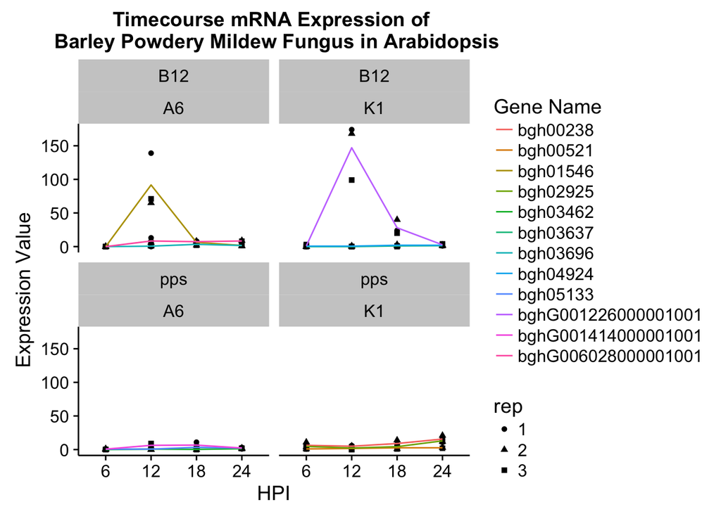

```r
cleaned_data %>%
    mutate(time.value = str_replace(time.point, "hpi", ""),
           time.hpi = str_c("hpi.", time.value)) %>%
    select(1:3,5:7) %>%
    merge(., top.hits) %>%
    arrange(as.numeric(time.value)) -> p.tbl

  p <- ggplot(p.tbl,
              aes(x=factor(time.value, levels = unique(time.value)),
                  y = value,
                  shape = rep)) +
    geom_point() +
    stat_summary(aes(y= value,
                     group = gene.name,
                     color = gene.name),
                     fun.y = mean,
                     geom = "line") +
    theme_cowplot() +
    facet_wrap(plant ~ fungus) +
    labs(title = "Timecourse mRNA Expression of \n Barley Powdery Mildew Fungus in Arabidopsis",
         x = "HPI",
         y = "Expression Value",
         color =  "Gene Name")
  p
```